# R Notebook

```r
library(dplyr)
college <- CollegeClusterData
glimpse(college)
```

```
Observations: 5,709
Variables: 27
$ UNITID         <dbl> 100654, 100663, 100937, 104717, 142887, 143048...
$ INSTNM         <chr> "Alabama A & M University", "University of Ala...
$ CITY           <chr> "Normal", "Birmingham", "Birmingham", "Phoenix...
$ STABBR         <chr> "AL", "AL", "AL", "AZ", "IL", "IL", "IL", "IL"...
$ ZIP            <chr> "35762", "35294-0110", "35254", "85017", "6060...
$ LATITUDE       <dbl> 34.7834, 33.5022, 33.5155, 33.5122, 41.8778, 4...
$ LONGITUDE      <dbl> -86.5685, -86.8092, -86.8536, -112.1299, -87.6...
$ LOCALE         <dbl> 12, 12, 12, 11, 11, 11, 13, 21, 21, 32, 13, 32...
$ CONTROL        <dbl> 1, 1, 2, 3, 3, 2, 2, 2, 1, 2, 1, 2, 3, 2, 3, 3...
$ DISTANCEONLY   <lgl> FALSE, FALSE, FALSE, FALSE, FALSE, FALSE, FALS...
$ PREDDEG        <dbl> 3, 3, 3, 3, 3, 3, 3, 3, 1, 4, 2, 3, 2, 3, 1, 1...
$ TUITFTE        <dbl> 9063, 9033, 11928, 10748, 24434, 28093, 17277,...
$ AVGFACSAL      <dbl> 7079, 10170, 7513, 5473, 4136, 9208, 7186, 706...
$ ADM_RATE       <dbl> 0.8989, 0.8673, 0.6422, 0.5480, 0.9300, 0.7184...
$ SAT_AVG        <dbl> 823, 1146, 1177, NA, NA, 1065, NA, 1011, NA, N...
$ UGDS           <dbl> 4051, 11200, 1181, 34643, 406, 2641, 2504, 323...
$ UGDS_WHITE     <dbl> 0.0279, 0.5987, 0.8103, 0.4427, 0.5394, 0.4559...
$ UGDS_BLACK     <dbl> 0.9501, 0.2590, 0.0940, 0.2075, 0.1232, 0.0299...
$ UGDS_HISP      <dbl> 0.0089, 0.0258, 0.0305, 0.1452, 0.2488, 0.0629...
$ UGDS_ASIAN     <dbl> 0.0022, 0.0518, 0.0390, 0.0437, 0.0394, 0.1253...
$ IND_INC_PCT_LO <chr> "0.947019868", "0.701354241", "1", "0.64469673...
$ IND_INC_PCT_M1 <chr> "PrivacySuppressed", "0.142551675", "0", "0.12...
$ IND_INC_PCT_M2 <chr> "PrivacySuppressed", "0.086956522", "0", "0.11...
$ IND_INC_PCT_H1 <chr> "PrivacySuppressed", "0.05274412", "0", "0.072...
$ IND_INC_PCT_H2 <chr> "0", "0.016393443", "0", "0.042993798", "0", "...
$ PCTFLOAN       <dbl> 0.8204, 0.5397, 0.4939, 0.6248, 0.8403, 0.4835...
$ GRAD_DEBT_MDN  <chr> "33611.5", "23117", "27000", "18750", "27000",...
```

Latitude and longitudes are not going to be used for this assignment. It could be use to group the close institutions but “city” will be used instead. However, if we plot we see that there is even wrong coordinates in the data:

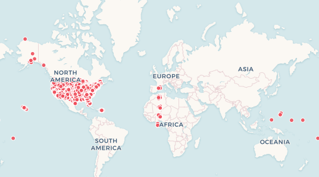

```r
length(table(college$CITY))
```

```
[1] 2242
```

The only location related attribute that will be used is “STABBR”, which is the state code. “UNITID” will be used because institution names can occur more than one time if one institution has more than one campus.

| UNITID | STABBR | LOCALE | CONTROL | DISTANCEONLY | PREDDEG | TUITFTE | AVGFACSAL | ADM_RATE | SAT_AVG | UGDS | UGDS_WHITE | UGDS_BLACK | UGDS_HISP | UGDS_ASIAN | IND_INC_PCT_LO | IND_INC_PCT_M1 | IND_INC_PCT_M2 | IND_INC_PCT_H1 | IND_INC_PCT_H2 | PCTFLOAN | GRAD_DEBT_MDN |
| --- | --- | --- | --- | --- | --- | --- | --- | --- | --- | --- | --- | --- | --- | --- | --- | --- | --- | --- | --- | --- | --- |
| 100654 | AL | 12 | 1 | FALSE | 3 | 9063 | 7079 | 0.8989 | 823 | 4051 | 0.0279 | 0.9501 | 0.0089 | 0.0022 | 0.947019868 | PrivacySuppressed | PrivacySuppressed | PrivacySuppressed | 0 | 0.8204 | 33611.5 |
| 100663 | AL | 12 | 1 | FALSE | 3 | 9033 | 10170 | 0.8673 | 1146 | 11200 | 0.5987 | 0.2590 | 0.0258 | 0.0518 | 0.701354241 | 0.142551675 | 0.086956522 | 0.05274412 | 0.016393443 | 0.5397 | 23117 |
| 100937 | AL | 12 | 2 | FALSE | 3 | 11928 | 7513 | 0.6422 | 1177 | 1181 | 0.8103 | 0.0940 | 0.0305 | 0.0390 | 1 | 0 | 0 | 0 | 0 | 0.4939 | 27000 |
| 104717 | AZ | 11 | 3 | FALSE | 3 | 10748 | 5473 | 0.5480 | NA | 34643 | 0.4427 | 0.2075 | 0.1452 | 0.0437 | 0.644696731 | 0.129051473 | 0.110410316 | 0.072847682 | 0.042993798 | 0.6248 | 18750 |
| 142887 | IL | 11 | 3 | FALSE | 3 | 24434 | 4136 | 0.9300 | NA | 406 | 0.5394 | 0.1232 | 0.2488 | 0.0394 | 1 | 0 | 0 | 0 | 0 | 0.8403 | 27000 |
| 143048 | IL | 11 | 2 | FALSE | 3 | 28093 | 9208 | 0.7184 | 1065 | 2641 | 0.4559 | 0.0299 | 0.0629 | 0.1253 | 0.90990991 | PrivacySuppressed | PrivacySuppressed | PrivacySuppressed | PrivacySuppressed | 0.4835 | 25000 |

```r
dim(data.frame(table(college$STABBR)))
```

```
[1] 59  2
```

There are 59 state postcode in the data.

Before missing value imputation, we change the class of categorical values:

```r
glimpse(college)
```

```
Observations: 5,709
Variables: 22
$ UNITID         <dbl> 100654, 100663, 100937, 104717, 142887, 143048, 143084, 143118, 143215, 143233, 143279, 143288, 10480...
$ STABBR         <chr> "AL", "AL", "AL", "AZ", "IL", "IL", "IL", "IL", "IL", "IN", "IL", "IL", "AZ", "IL", "IL", "IL", "IL",...
$ LOCALE         <dbl> 12, 12, 12, 11, 11, 11, 13, 21, 21, 32, 13, 32, 11, 12, 23, 21, 21, 11, 11, 12, 11, 11, 21, 41, 11, 2...
$ CONTROL        <dbl> 1, 1, 2, 3, 3, 2, 2, 2, 1, 2, 1, 2, 3, 2, 3, 3, 3, 3, 3, 3, 3, 3, 3, 1, 2, 3, 2, 1, 2, 2, 1, 3, 1, 1,...
$ DISTANCEONLY   <dbl> 0, 0, 0, 0, 0, 0, 0, 0, 0, 0, 0, 0, 0, 0, 0, 0, 0, 0, 0, 0, 0, 0, 0, 0, 0, 0, 0, 0, 0, 0, 0, 0, 0, 0,...
$ PREDDEG        <dbl> 3, 3, 3, 3, 3, 3, 3, 3, 1, 4, 2, 3, 2, 3, 1, 1, 1, 1, 1, 1, 1, 1, 1, 2, 4, 1, 4, 3, 4, 3, 1, 1, 1, 1,...
$ TUITFTE        <dbl> 9063, 9033, 11928, 10748, 24434, 28093, 17277, 11016, 3050, 3432, 1497, 12449, 8537, 18539, 12209, 99...
$ AVGFACSAL      <dbl> 7079, 10170, 7513, 5473, 4136, 9208, 7186, 7064, 7256, 5416, 6730, 5861, 3848, 8424, NA, NA, NA, NA, ...
$ ADM_RATE       <dbl> 0.8989, 0.8673, 0.6422, 0.5480, 0.9300, 0.7184, 0.5867, 0.7595, NA, NA, NA, 0.6799, NA, 0.6694, NA, N...
$ SAT_AVG        <dbl> 823, 1146, 1177, NA, NA, 1065, NA, 1011, NA, NA, NA, 1034, NA, 1163, NA, NA, NA, NA, NA, NA, NA, NA, ...
$ UGDS           <dbl> 4051, 11200, 1181, 34643, 406, 2641, 2504, 3236, 9862, NA, 4736, 539, 2238, 4823, 395, 105, 83, 84, 1...
$ UGDS_WHITE     <dbl> 0.0279, 0.5987, 0.8103, 0.4427, 0.5394, 0.4559, 0.7772, 0.6143, 0.6386, NA, 0.7145, 0.8683, 0.4303, 0...
$ UGDS_BLACK     <dbl> 0.9501, 0.2590, 0.0940, 0.2075, 0.1232, 0.0299, 0.0403, 0.0853, 0.2162, NA, 0.1039, 0.0909, 0.2690, 0...
$ UGDS_HISP      <dbl> 0.0089, 0.0258, 0.0305, 0.1452, 0.2488, 0.0629, 0.0611, 0.2052, 0.0391, NA, 0.1153, 0.0148, 0.1649, 0...
$ UGDS_ASIAN     <dbl> 0.0022, 0.0518, 0.0390, 0.0437, 0.0394, 0.1253, 0.0176, 0.0213, 0.0087, NA, 0.0133, 0.0000, 0.0125, 0...
$ IND_INC_PCT_LO <chr> "0.947019868", "0.701354241", "1", "0.644696731", "1", "0.90990991", "PrivacySuppressed", "0.64424778...
$ IND_INC_PCT_M1 <chr> "PrivacySuppressed", "0.142551675", "0", "0.129051473", "0", "PrivacySuppressed", "PrivacySuppressed"...
$ IND_INC_PCT_M2 <chr> "PrivacySuppressed", "0.086956522", "0", "0.110410316", "0", "PrivacySuppressed", "PrivacySuppressed"...
$ IND_INC_PCT_H1 <chr> "PrivacySuppressed", "0.05274412", "0", "0.072847682", "0", "PrivacySuppressed", "0", "0.077876106", ...
$ IND_INC_PCT_H2 <chr> "0", "0.016393443", "0", "0.042993798", "0", "PrivacySuppressed", "0", "0.030088496", "0.004563005", ...
$ PCTFLOAN       <dbl> 0.8204, 0.5397, 0.4939, 0.6248, 0.8403, 0.4835, 0.5880, 0.7184, 0.2343, NA, 0.1303, 0.8380, 0.8631, 0...
$ GRAD_DEBT_MDN  <chr> "33611.5", "23117", "27000", "18750", "27000", "25000", "27000", "22500", "7376.5", NA, "6375", "2456...
```

```r
shouldBeCategorical <- c('STABBR', 'LOCALE', 'CONTROL', 'DISTANCEONLY', 'PREDDEG')
for(v in shouldBeCategorical) {
  college[[v]] <- as.factor(college[[v]])
}
```

In the “IND_INC_PCT_L0”, “IND_INC_PCT_M1”, “IND_INC_PCT_M2”, “IND_INC_PCT_H1” and “IND_INC_PCT_H2” attributes, there is a value named as “PrivacySuppressed”. This value is converted into NA. On the other hand, these attributes’ class should be numerical.

```r
college[college == "PrivacySuppressed"] <- NA
shouldBeNumerical <- c('IND_INC_PCT_LO', 'IND_INC_PCT_M1', 'IND_INC_PCT_M2', 'IND_INC_PCT_H1','IND_INC_PCT_H2', 'GRAD_DEBT_MDN')
for(v in shouldBeNumerical) {
  college[[v]] <- as.numeric(as.character(college[[v]]))
}
glimpse(college)
```

```
Observations: 5,709
Variables: 22
$ UNITID         <dbl> 100654, 100663, 100937, 104717, 142887, 143048...
$ STABBR         <fct> AL, AL, AL, AZ, IL, IL, IL, IL, IL, IN, IL, IL...
$ LOCALE         <fct> 12, 12, 12, 11, 11, 11, 13, 21, 21, 32, 13, 32...
$ CONTROL        <fct> 1, 1, 2, 3, 3, 2, 2, 2, 1, 2, 1, 2, 3, 2, 3, 3...
$ DISTANCEONLY   <fct> FALSE, FALSE, FALSE, FALSE, FALSE, FALSE, FALS...
$ PREDDEG        <fct> 3, 3, 3, 3, 3, 3, 3, 3, 1, 4, 2, 3, 2, 3, 1, 1...
$ TUITFTE        <dbl> 9063, 9033, 11928, 10748, 24434, 28093, 17277,...
$ AVGFACSAL      <dbl> 7079, 10170, 7513, 5473, 4136, 9208, 7186, 706...
$ ADM_RATE       <dbl> 0.8989, 0.8673, 0.6422, 0.5480, 0.9300, 0.7184...
$ SAT_AVG        <dbl> 823, 1146, 1177, NA, NA, 1065, NA, 1011, NA, N...
$ UGDS           <dbl> 4051, 11200, 1181, 34643, 406, 2641, 2504, 323...
$ UGDS_WHITE     <dbl> 0.0279, 0.5987, 0.8103, 0.4427, 0.5394, 0.4559...
$ UGDS_BLACK     <dbl> 0.9501, 0.2590, 0.0940, 0.2075, 0.1232, 0.0299...
$ UGDS_HISP      <dbl> 0.0089, 0.0258, 0.0305, 0.1452, 0.2488, 0.0629...
$ UGDS_ASIAN     <dbl> 0.0022, 0.0518, 0.0390, 0.0437, 0.0394, 0.1253...
$ IND_INC_PCT_LO <dbl> 0.9470199, 0.7013542, 1.0000000, 0.6446967, 1....
$ IND_INC_PCT_M1 <dbl> NA, 0.14255167, 0.00000000, 0.12905147, 0.0000...
$ IND_INC_PCT_M2 <dbl> NA, 0.08695652, 0.00000000, 0.11041032, 0.0000...
$ IND_INC_PCT_H1 <dbl> NA, 0.05274412, 0.00000000, 0.07284768, 0.0000...
$ IND_INC_PCT_H2 <dbl> 0.000000000, 0.016393443, 0.000000000, 0.04299...
$ PCTFLOAN       <dbl> 0.8204, 0.5397, 0.4939, 0.6248, 0.8403, 0.4835...
$ GRAD_DEBT_MDN  <dbl> 33611.5, 23117.0, 27000.0, 18750.0, 27000.0, 2...
```

Checking the missing values:

```r
sapply(college, function(x) sum(is.na(x)))
```

```
        UNITID         STABBR         LOCALE        CONTROL   DISTANCEONLY        PREDDEG
             0              0             10              0              7              0
       TUITFTE      AVGFACSAL       ADM_RATE        SAT_AVG           UGDS     UGDS_WHITE
            12           2066           3823           4338            271            271
    UGDS_BLACK      UGDS_HISP     UGDS_ASIAN IND_INC_PCT_LO IND_INC_PCT_M1 IND_INC_PCT_M2
           271            271            271           1885           2738           3420
IND_INC_PCT_H1 IND_INC_PCT_H2       PCTFLOAN  GRAD_DEBT_MDN
          4164           3637            284           1162
```

For missing value imputation, “missMDA” package will be used. Based on dimensionality reduction methods, this packae succesfully imputes datasets with quantitative, categorical and mixed variables. Indeed, it imputes data with principal component methods that take into account the similarities between the observations and the relationships between variables. It has proven to be really competitive in terms of quality of the prediction compared to the state of art methods.

```r
library(missMDA)
np <- estim_ncpFAMD(college)#3
```

For leave-one-out cross-validation (method.cv=“loo”), each cell of the data matrix is alternatively removed and predicted with a FAMD model using ncp.min to ncp.max dimensions. The number of components which leads to the smallest mean square error of prediction (MSEP) is retained. For the Kfold cross-validation (method.cv=“Kfold”), pNA percentage of missing values is inserted at random in the data matrix and predicted with a FAMD model using ncp.min to ncp.max dimensions. This process is repeated nbsim times. The number of components which leads to the smallest MSEP is retained. More precisely, for both cross-validation methods, the missing entries are predicted using the imputeFAMD function, it means using it means using the regularized iterative FAMD algorithm (method=“Regularized”) or the iterative FAMD algorithm (method=“EM”). The regularized version is more appropriate to avoid overfitting issues.

As default, method is “regularized” in “imputeFAMD” function. This is to avoid the overfitting problems. In the regularized algorithm, the singular values of FAMD are shrinked.

```r
second_part_data <-res.impute$completeObs[,-c(1:6)]
first_part_data <- college[,c(1:6)]
college_data <- cbind(first_part_data, second_part_data)
head(college_data)
```

|  | UNITID | STABBR | LOCALE | CONTROL | DISTANCEONLY | PREDDEG | TUITFTE | AVGFACSAL | ADM_RATE | SAT_AVG | UGDS | UGDS_WHITE | UGDS_BLACK | UGDS_HISP | UGDS_ASIAN | IND_INC_PCT_LO | IND_INC_PCT_M1 | IND_INC_PCT_M2 | IND_INC_PCT_H1 | IND_INC_PCT_H2 | PCTFLOAN | GRAD_DEBT_MDN |
| --- | --- | --- | --- | --- | --- | --- | --- | --- | --- | --- | --- | --- | --- | --- | --- | --- | --- | --- | --- | --- | --- | --- |
| 1 | 100654 | AL | 12 | 1 | FALSE | 3 | 9063 | 7079 | 0.8989 | 823.0000 | 4051 | 0.0279 | 0.9501 | 0.0089 | 0.0022 | 0.9470199 | 0.1096728 | 0.05883797 | 0.01819590 | 0.00000000 | 0.8204 | 33611.5 |
| 2 | 100663 | AL | 12 | 1 | FALSE | 3 | 9033 | 10170 | 0.8673 | 1146.0000 | 11200 | 0.5987 | 0.2590 | 0.0258 | 0.0518 | 0.7013542 | 0.1425517 | 0.08695652 | 0.05274412 | 0.01639344 | 0.5397 | 23117.0 |
| 3 | 100937 | AL | 12 | 2 | FALSE | 3 | 11928 | 7513 | 0.6422 | 1177.0000 | 1181 | 0.8103 | 0.0940 | 0.0305 | 0.0390 | 1.0000000 | 0.0000000 | 0.00000000 | 0.00000000 | 0.00000000 | 0.4939 | 27000.0 |
| 4 | 104717 | AZ | 11 | 3 | FALSE | 3 | 10748 | 5473 | 0.5480 | 1106.0456 | 34643 | 0.4427 | 0.2075 | 0.1452 | 0.0437 | 0.6446967 | 0.1290515 | 0.11041032 | 0.07284768 | 0.04299380 | 0.6248 | 18750.0 |
| 5 | 142887 | IL | 11 | 3 | FALSE | 3 | 24434 | 4136 | 0.9300 | 979.2571 | 406 | 0.5394 | 0.1232 | 0.2488 | 0.0394 | 1.0000000 | 0.0000000 | 0.00000000 | 0.00000000 | 0.00000000 | 0.8403 | 27000.0 |
| 6 | 143048 | IL | 11 | 2 | FALSE | 3 | 28093 | 9208 | 0.7184 | 1065.0000 | 2641 | 0.4559 | 0.0299 | 0.0629 | 0.1253 | 0.9099099 | 0.1331910 | 0.08120773 | 0.03630526 | 0.01590986 | 0.4835 | 25000.0 |

```r
college_data[ , 3][is.na(data[ , 2] ) ] = 21
```

[output not shown]

Choosing the attributes we are interested:

```r
names(college_data)
```

```
 [1] "UNITID"         "STABBR"         "LOCALE"         "CONTROL"
 [5] "DISTANCEONLY"   "PREDDEG"        "TUITFTE"        "AVGFACSAL"
 [9] "ADM_RATE"       "SAT_AVG"        "UGDS"           "UGDS_WHITE"
[13] "UGDS_BLACK"     "UGDS_HISP"      "UGDS_ASIAN"     "IND_INC_PCT_LO"
[17] "IND_INC_PCT_M1" "IND_INC_PCT_M2" "IND_INC_PCT_H1" "IND_INC_PCT_H2"
[21] "PCTFLOAN"       "GRAD_DEBT_MDN"
```

|  | UNITID | STABBR | LOCALE | DISTANCEONLY | PREDDEG | TUITFTE | ADM_RATE | SAT_AVG | UGDS |
| --- | --- | --- | --- | --- | --- | --- | --- | --- | --- |
| 1 | -0.1858890 | AL | 12 | FALSE | 3 | -0.03402938 | 1.5638585 | -2.74777515 | 0.20377373 |
| 2 | -0.1858796 | AL | 12 | FALSE | 3 | -0.03751641 | 1.3217307 | 1.54374980 | 1.49520683 |
| 3 | -0.1855921 | AL | 12 | FALSE | 3 | 0.29898213 | -0.4030467 | 1.95562990 | -0.31467823 |
| 4 | -0.1816258 | AZ | 11 | FALSE | 3 | 0.16182556 | -1.1248327 | 0.92909565 | 5.73007411 |
| 5 | -0.1415747 | IL | 11 | FALSE | 3 | 1.75260935 | 1.8021551 | 0.02252111 | -0.45467832 |
| 6 | -0.1414058 | IL | 11 | FALSE | 3 | 2.17791096 | 0.1808184 | 0.46754695 | -0.05093612 |

```r
summary(disMat)
```

```
16293486 dissimilarities, summarized :
   Min. 1st Qu.  Median    Mean 3rd Qu.    Max.
 0.0000  0.2737  0.3877  0.3459  0.4095  0.7148
Metric :  mixed ;  Types = N, N, N, N, I, I, I, I
Number of objects : 5709
```

Output most similar pair:

|  | UNITID | STABBR | LOCALE | DISTANCEONLY | PREDDEG | TUITFTE | ADM_RATE | SAT_AVG | UGDS |
| --- | --- | --- | --- | --- | --- | --- | --- | --- | --- |
| 5434 | 10236809 | AL | 21 | FALSE | 0 | 9748.706 | 0.8402926 | 921.9372 | -2896.966 |
| 5433 | 10236808 | AL | 21 | FALSE | 0 | 9748.706 | 0.8402926 | 921.9372 | -2896.966 |

Output most dissimilar pair:

|  | UNITID | STABBR | LOCALE | DISTANCEONLY | PREDDEG | TUITFTE | ADM_RATE | SAT_AVG | UGDS |
| --- | --- | --- | --- | --- | --- | --- | --- | --- | --- |
| 5483 | 48285706 | GA | 21 | FALSE | 0 | 9942.645 | 1.162390 | 645.8797 | -19481.82 |
| 1739 | 196680 | NY | 13 | TRUE | 3 | 3944.000 | 0.530416 | 1176.3218 | 37440.00 |

Calculate silhouette width for many k using PAM:

```r
sil_width <- c(NA)
for(i in 2:10){
  pam_fit <- pam(gower_mat, diss=T,k=i)
  sil_width[i]<-pam_fit$silinfo$avg.width
}
```

Plot silhouette width:

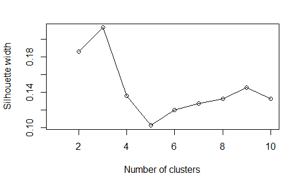

```r
plot(1:10, sil_width, xlab = "Number of clusters", ylab = "Silhouette width")
lines(1:10, sil_width)
```

Since higher is the better, 3 is chosen as the cluster number.

```r
pam_results$the_summary
```

```
[[1]]
     STABBR         LOCALE    DISTANCEONLY PREDDEG     TUITFTE
 NY     : 284   11     :618   FALSE:1937   0:   5   Min.   :     0
 PA     : 105   13     :277   TRUE :  21   1:  75   1st Qu.:  7681
 CA     : 100   21     :266                2:  31   Median : 12186
 IL     :  90   12     :236                3:1694   Mean   : 13546
 MA     :  82   32     :161                4: 153   3rd Qu.: 17184
 OH     :  64   33     :123                         Max.   :123492
 (Other):1233   (Other):277
    ADM_RATE         SAT_AVG          UGDS            cluster
 Min.   :0.0000   Min.   : 666   Min.   : -193.3   Min.   :1
 1st Qu.:0.5730   1st Qu.:1008   1st Qu.:  798.5   1st Qu.:1
 Median :0.6643   Median :1045   Median : 1986.0   Median :1
 Mean   :0.6492   Mean   :1060   Mean   : 4405.6   Mean   :1
 3rd Qu.:0.7407   3rd Qu.:1094   3rd Qu.: 4662.5   3rd Qu.:1
 Max.   :1.0000   Max.   :1534   Max.   :50919.0   Max.   :1


[[2]]
     STABBR         LOCALE    DISTANCEONLY PREDDEG     TUITFTE
 CA     : 405   21     :971   FALSE:2524   0:  25   Min.   :     0
 FL     : 173   13     :344   TRUE :   6   1:2225   1st Qu.:  3347
 OH     : 145   11     :299                2:  85   Median :  6934
 PA     : 143   12     :290                3: 115   Mean   :  8136
 IL     : 102   41     :143                4:  80   3rd Qu.: 10546
 MO     :  88   33     :140                         Max.   :207213
 (Other):1474   (Other):343
    ADM_RATE         SAT_AVG            UGDS             cluster
 Min.   :0.0000   Min.   : 645.9   Min.   :-19481.8   Min.   :2
 1st Qu.:0.7129   1st Qu.: 963.9   1st Qu.:    62.0   1st Qu.:2
 Median :0.7522   Median : 981.1   Median :   144.5   Median :2
 Mean   :0.7392   Mean   : 987.0   Mean   :   921.7   Mean   :2
 3rd Qu.:0.7767   3rd Qu.:1001.8   3rd Qu.:   479.5   3rd Qu.:2
 Max.   :1.1624   Max.   :1483.0   Max.   : 33439.0   Max.   :2


[[3]]
     STABBR        LOCALE    DISTANCEONLY PREDDEG    TUITFTE
 TX     :213   11     :361   FALSE:1216   0:  6   Min.   :    0
 CA     : 82   13     :158   TRUE :   5   1:183   1st Qu.: 1653
 FL     : 53   41     :127                2:962   Median : 3029
 NC     : 53   12     :123                3: 39   Mean   : 5181
 NY     : 53   21     :117                4: 31   3rd Qu.: 6772
 PA     : 52   33     :100                        Max.   :95815
 (Other):715   (Other):235
    ADM_RATE         SAT_AVG          UGDS          cluster
 Min.   :0.0000   Min.   : 755   Min.   : -211   Min.   :3
 1st Qu.:0.6740   1st Qu.:1001   1st Qu.:  445   1st Qu.:3
 Median :0.7098   Median :1021   Median : 2167   Median :3
 Mean   :0.7026   Mean   :1021   Mean   : 4365   Mean   :3
 3rd Qu.:0.7421   3rd Qu.:1045   3rd Qu.: 5549   3rd Qu.:3
 Max.   :1.0000   Max.   :1187   Max.   :87017   Max.   :3
```

|  | UNITID | STABBR | LOCALE | DISTANCEONLY | PREDDEG | TUITFTE | ADM_RATE | SAT_AVG | UGDS |
| --- | --- | --- | --- | --- | --- | --- | --- | --- | --- |
| 1743 | 197018 | NY | 11 | FALSE | 3 | 13091 | 0.6975450 | 1022.9939 | 1814 |
| 4468 | 444361 | CA | 21 | FALSE | 1 | 11356 | 0.7374431 | 979.3618 | 103 |
| 2796 | 224271 | TX | 11 | FALSE | 2 | 5776 | 0.6999249 | 1010.8458 | 114 |

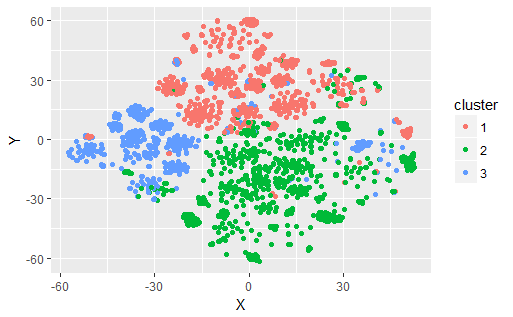